# Reproducible Research - Project 1

Kier O’Neil

August 3, 2016

# Objective

Analyse and answer various questions about the activity dataset which reports a person’s steps every five minutes over the course of a day.  
Each day has 288 records.  
## Load Libraries

```r
rm(list=ls())

setwd("C:/Users/Kier/Documents/Analytics Course/04_ReproducibleResearch/Project1")


library(dplyr)
```

```r
library(readr)
library(ggplot2)
library(rpart)
library(lubridate)
```

## 1. Code for reading in the dataset and/or processing the data

Get raw data

```r
activity_raw <- read_csv("activity.csv")
```

## Initial Findings

This query shows that there are several days with all NA values. Since one of the days is the very first date and one is the very last date, they will be trimmed from the final data set as they are not representative of the rest of the data set.  
Let’s see what other days have NAs.

```r
range(activity_raw$date)
```

```
## [1] "2012-10-01" "2012-11-30"
```

```r
activity_raw %>%
    group_by(date) %>%
    filter(is.na(steps)) %>%
    summarise(num_of_na = length(steps))
```

```
## # A tibble: 8 x 2
##         date num_of_na
##       <date>     <int>
## 1 2012-10-01       288
## 2 2012-10-08       288
## 3 2012-11-01       288
## 4 2012-11-04       288
## 5 2012-11-09       288
## 6 2012-11-10       288
## 7 2012-11-14       288
## 8 2012-11-30       288
```

The second issue is with the 2nd day, 2012-10-02. It contains all zeros except for two entries.

```r
# Retrieve all records for Day 2, October 12, 2012
b <- activity_raw %>%
    filter(date == ymd("2012-10-02"))
# Get records where steps == zero on Oct 12, 2012
c <- b %>%
    filter(steps == 0)

dim(b)
```

```
## [1] 288   3
```

```r
dim(c)
```

```
## [1] 286   3
```

We can see that 286 of the 288 records for 2012-10-02 has a value of zero, which may indicate the the subject was not wearing the device for most of the day.

For these reasons 2012-10-01, 2012-10-02 & 2012-11-30 will be omitted from the analysis test set.

```r
ar_trimmed <- activity_raw %>%
    filter(date >= ymd("2012-10-03"), date < ymd("2012-11-30"))
```

Part of the assignment is to impute NA values. Let’s make sure that we still have a few NAs to work with.

```r
ar_trimmed %>%
    filter(is.na(steps))
```

```
## # A tibble: 1,728 x 3
##    steps       date interval
##    <int>     <date>    <int>
## 1     NA 2012-10-08        0
## 2     NA 2012-10-08        5
## 3     NA 2012-10-08       10
## 4     NA 2012-10-08       15
## 5     NA 2012-10-08       20
## 6     NA 2012-10-08       25
## 7     NA 2012-10-08       30
## 8     NA 2012-10-08       35
## 9     NA 2012-10-08       40
## 10    NA 2012-10-08       45
## # ... with 1,718 more rows
```

There are still 1,728 NAs that can be imputed

## Remove unneeded variables

```r
rm(b, c)
```

# Create Dataset with With NAs removed

This dataset removes all records with NAs, not just the first and last days.

```r
ar_na_omit <- na.omit(ar_trimmed)
```

### Summarise total number of steps taken per day

```r
total_steps_na_omit <- ar_na_omit %>%
    select(date, interval, steps) %>%
    group_by(date) %>%
    summarise(total_steps = sum(steps))
```

## 2. Histogram of the total number of steps taken each day

### NAs omitted

```r
p <- ggplot(total_steps_na_omit, aes(total_steps)) +
    geom_histogram(bins = 20)
```

## 3. Mean and median number of steps taken each day

Calculate and report the mean and median of the total number of steps taken per day with NA records omitted.

```r
(total_steps_mean <- mean(total_steps_na_omit$total_steps))
```

```
## [1] 10970.81
```

```r
(total_steps_median <- median(total_steps_na_omit$total_steps))
```

```
## [1] 10890
```

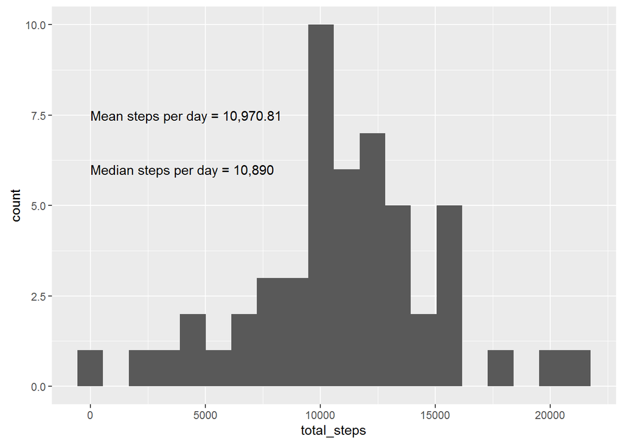

```r
p <- p + annotate("text", x = 0, y = c(7.5, 6),
                  label = c("Mean steps per day = 10,970.81",
                            "Median steps per day = 10,890"),
                  hjust = 0)
p
```

## 4. Time series plot of the average number of steps taken

## 5. The 5-minute interval that, on average, contains the maximum number of steps

Make a time series plot (i.e. type = “l”) of the 5-minute interval (x-axis) and the average number of steps taken, averaged across all days (y-axis).  
Which 5-minute interval, on average across all the days in the dataset, contains the maximum number of steps?  
*NOTE: This dataset omits all NAs*

```r
average_per_interval <- ar_na_omit %>%
    select(date, interval, steps) %>%
    group_by(interval) %>%
    summarise(average_per_5_minutes = mean(steps))
```

Determine the interval with the maximum average steps

```r
max_interval <- average_per_interval %>%
    filter(average_per_5_minutes == max(average_per_5_minutes))

max_interval <- max_interval[1]
max_interval
```

```
## # A tibble: 1 x 1
##   interval
##      <int>
## 1      835
```

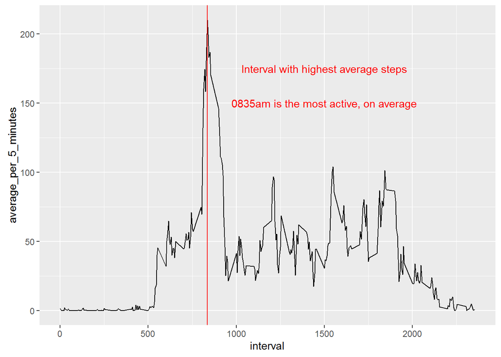

```r
ggplot(average_per_interval, aes(interval, average_per_5_minutes)) + geom_line() +
geom_vline(aes(xintercept = max_interval), colour = "red") +
annotate("text", x=1500, y = c(175, 150),
         label = c("Interval with highest average steps",
                   "0835am is the most active, on average"),
         colour = "red")
```

# Create dataset with NAs imputed by a formula

## 6. Code to describe and show a strategy for imputing missing data

### Strategy for imputing NA values:

To impute the values of the NAs in ‘steps’ I decided to use a the rpart library which uses recursive partitioning. I like it because it can impute the value based on any number of parameters even though this case only derives it based on the interval that it occurs in.

Start with the trimmed raw data set

```r
ar_imputed <- ar_trimmed
```

Impute the missing ‘steps’ using rpart

```r
#library(rpart)

# Create prediction formula
predicted_steps <- rpart(steps ~ interval, data = ar_imputed[!is.na(ar_imputed$steps),],
                         method = "anova")

# Apply prediction to ar_imputed NA records
ar_imputed$steps[is.na(ar_imputed$steps)] <- predict(predicted_steps,
                                                     ar_imputed[is.na(ar_imputed$steps),])

# Summarise total number of steps taken per day
total_steps_imputed <- ar_imputed %>%
    select(date, interval, steps) %>%
    group_by(date) %>%
    summarise(total_steps = sum(steps))

# Calculate mean steps per day
total_steps_imputed_mean <- mean(total_steps_imputed$total_steps)
total_steps_imputed_median <- median(total_steps_imputed$total_steps)
```

## 7. Histogram of the total number of steps taken each day after missing values are imputed.

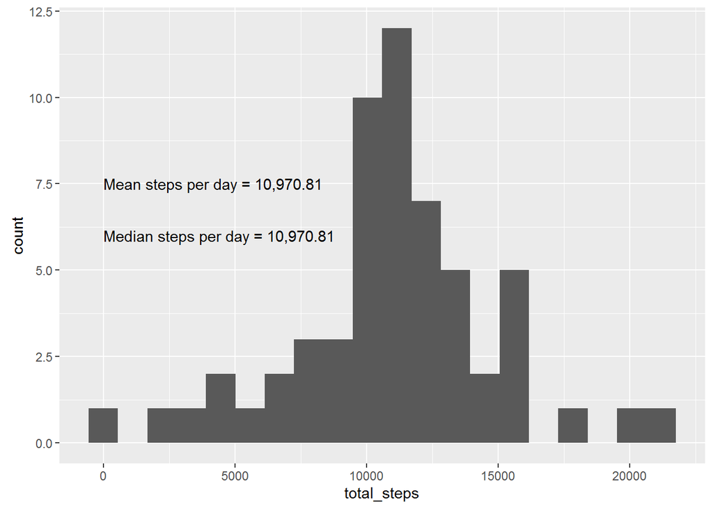

```r
p <- ggplot(total_steps_imputed, aes(total_steps)) +
     geom_histogram(bins = 20) +
     annotate("text", x = 0, y = c(7.5, 6),
              label = c("Mean steps per day = 10,970.81",
                        "Median steps per day = 10,970.81"),
                       hjust = 0)
p
```

Interesting that now the mean and the median are the same.

## 8. Panel plot comparing the average number of steps taken per 5-minute interval across weekdays and weekends.

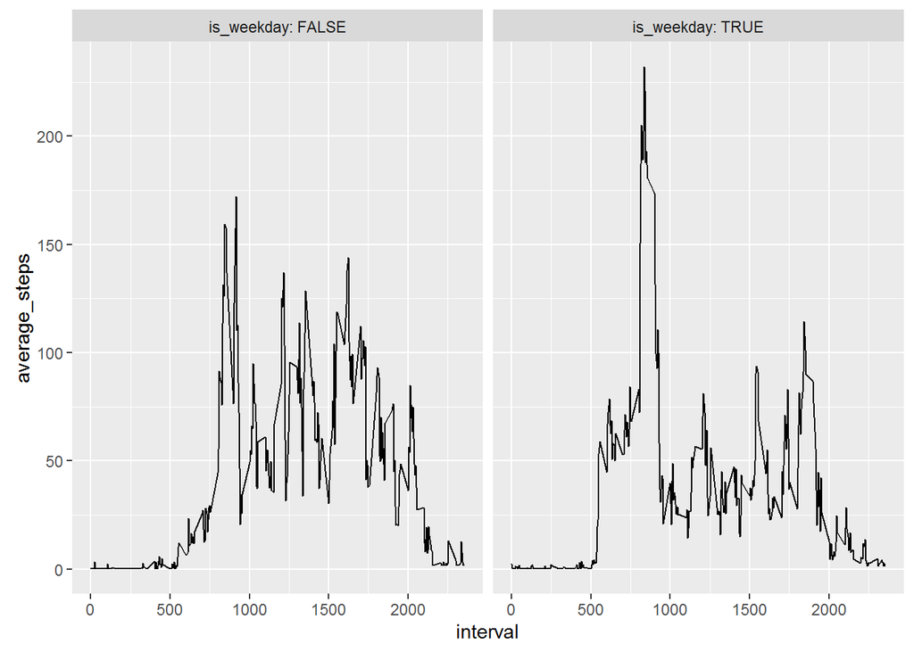

```r
is_weekday <- !(weekdays(as.Date(ar_imputed$date)) %in% c('Saturday','Sunday'))
ar_imputed_days <- cbind(is_weekday, ar_imputed)
ar_imputed_days$is_weekday <- is_weekday

total_steps_days <- ar_imputed_days %>%
    group_by(is_weekday, interval) %>%
    summarise(average_steps = mean(steps))

p <- ggplot(total_steps_days, aes(interval, average_steps)) +geom_line()
p + facet_wrap(~is_weekday, ncol=2, labeller = "label_both")
```